# NSW Road Crash Severity Prediction

STAT5003 - Group 07, Workshop 12

Sanskar | Robert | Haipeng | Chen | Yihan

May 2026

```r
library(ggplot2)
library(dplyr)
library(tidyr)
library(readr)
library(forcats)
library(scales)
library(knitr)
library(caret)
library(nnet)
library(rpart)
library(rpart.plot)
library(randomForest)
library(xgboost)
library(kknn)
library(e1071)
library(themis)
library(pROC)
library(flextable)
library(MLmetrics)

# Create plots output folder  -  all ggsave() calls write here for use in Presentation Rmd
dir.create("plots", showWarnings = FALSE)
```

```r
df <- read.csv("nsw_road_crash_merged_2020_2024.csv", check.names = FALSE)
cat("Dimensions:", nrow(df), "rows x", ncol(df), "cols\n")
str(df)
```

### 1 Problem Framing & Research Question

#### 1.1 Research Question

Given environmental conditions (weather, natural lighting, road surface, speed limit) and traffic unit characteristics (type of traffic unit, manoeuvre, number of units involved), can we predict the severity of a road crash in NSW as a three-class classification problem: Fatal, Injury, or Non-casualty?

#### 1.2 Motivation

NSW recorded 340 road fatalities in 2024, with over two-thirds occurring in regional areas (Transport for NSW, 2025), highlighting the need for data-driven approaches to understanding crash severity. Fatal crashes represent only approximately 1.4% of all crashes, introducing severe class imbalance that must be carefully addressed during modelling and evaluation.

A predictive model for crash severity has direct real-world value for the following stakeholders: NSW Traffic Management Authorities: By identifying key combinations of environmental and traffic characteristics associated with severe crashes, authorities can make targeted decisions such as adjusting speed limits and improving road design in high-risk areas.

Emergency Response Teams: Predicting crash severity based on environmental conditions in the early stages of an incident can support faster and more evidence-based allocation of ambulance and emergency resources. Policymakers and Insurance Institutions: Understanding which traffic unit types and environmental conditions are associated with higher severity risk can inform more precise road safety policies and insurance pricing models.

### 2 Dataset & Justification

#### 2.1 Dataset Overview

Table 1: Dataset Overview

| Item | Detail |
| --- | --- |
| Time Period | 2020 - 2024 |
| Data Sources | CRASH.xlsx + TRAFFIC UNIT.xlsx (TfNSW via data.gov.au) |
| Merge Key | Crash ID (left join) |
| Total Records | 170,962 |
| Total Variables | 59 |
| Target Variable | Degree of Crash (3-class classification) |
| Fatal | 2,416 (1.4%) |
| Injury | 114,355 (66.9%) |
| Non-casualty | 54,191 (31.7%) |

### 3 EDA & Insights

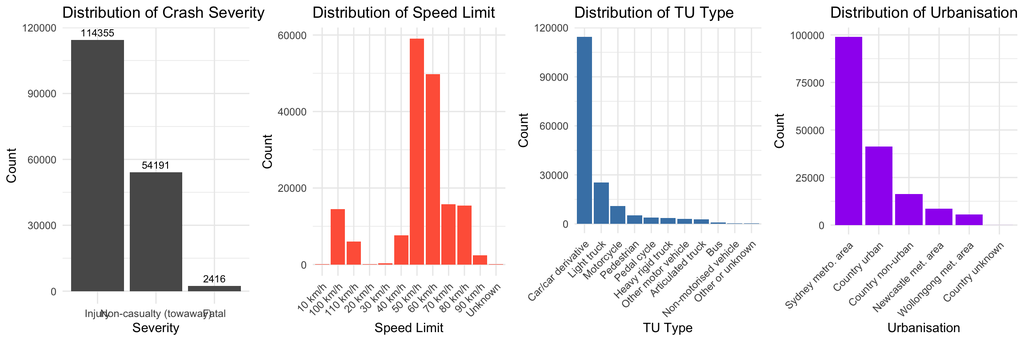

```r
library(gridExtra)

p1 <- ggplot(df, aes(x = fct_infreq(`Degree of crash`))) +
    geom_bar() +
    geom_text(stat = "count", aes(label = after_stat(count)), vjust = -0.5, size = 3) +
    labs(title = "Distribution of Crash Severity", x = "Severity", y = "Count") +
    theme_minimal() + theme(legend.position = "none")

p2 <- ggplot(df, aes(x = `Speed limit`)) +
  geom_bar(fill = "tomato") +
  labs(title = "Distribution of Speed Limit", x = "Speed Limit", y = "Count") +
  theme_minimal() +
  theme(axis.text.x = element_text(angle = 45, hjust = 1))

p3 <- ggplot(df, aes(x = fct_infreq(`TU type group`))) +
    geom_bar(fill = "steelblue") +
    labs(title = "Distribution of TU Type", x = "TU Type", y = "Count") +
    theme_minimal() +
    theme(axis.text.x = element_text(angle = 45, hjust = 1))

p4 <- ggplot(df, aes(x = fct_infreq(Urbanisation))) +
  geom_bar(fill = "purple") +
  labs(title = "Distribution of Urbanisation", x = "Urbanisation", y = "Count") +
  theme_minimal() +
  theme(axis.text.x = element_text(angle = 45, hjust = 1))

grid.arrange(p1, p2, p3, p4, nrow = 1)
```

- **Crash Severity:** Fatal crashes represent only 1.4% of records, indicating severe class imbalance that must be addressed during modelling.
- **Speed Limit:** Crashes are heavily concentrated in 50-60 km/h urban zones, reflecting higher traffic volume rather than elevated per-trip risk.
- **Traffic Unit Type:** Car/car derivatives dominate (~114,477), with pedestrians and motorcycles being rare but disproportionately associated with severe outcomes.
- **Urbanisation:** Sydney metro accounts for the most crashes (98,975), while Country non-urban regions show higher fatal proportions despite lower overall volume.

### 4 Data Preprocessing

All data-dependent steps are performed **within cross-validation folds** to prevent data leakage (James et al., 2021).

#### 4.1 Data Integration & TU-Level Feature Aggregation

```r
# Each row is one traffic unit  -  summarise binary flags per crash, then join back
tu_flags <- df %>%
  group_by(`Crash ID`) %>%
  summarise(
    has_motorcycle    = as.integer(any(`TU type group` == "Motorcycle")),
    has_heavy_vehicle = as.integer(any(`TU type group` %in% c("Articulated truck", "Heavy rigid truck", "Bus"))),
    has_pedestrian    = as.integer(any(`TU type group` == "Pedestrian")),
    has_cyclist       = as.integer(any(`TU type group` == "Pedal cycle")),
    tu_count          = n(),
    .groups = "drop"
  )

df <- df %>% left_join(tu_flags, by = "Crash ID")
cat("TU flags added. Rows:", nrow(df), "| New cols:", ncol(df), "\n")
```

#### 4.2 Feature Removal

```r
# Leakage: post-crash outcome counts that directly encode the target
leakage_cols <- c("No. killed", "No. seriously injured",
                  "No. moderately injured", "No. minor-other injured")

# Redundant: detailed severity is a finer version of the target column
redundant_target_cols <- c("Degree of crash - detailed")

# Identifiers and free-text location fields (no predictive signal)
id_cols <- c("Crash ID", "Traffic unit ID", "Street of crash",
             "Street of travel", "Town", "Identifying feature",
             "Identifying feature type", "Conurbation 1")

# High-NA columns (>75% missing  -  confirmed from inspection)
high_na_cols <- c("Primary hazardous feature", "Primary temporary feature",
                  "Object hit 2", "DCA supplement", "Object hit 1",
                  "Primary permanent feature")

redundant_cols <- c("Route no.", "RUM - code", "RUM - description",
                    "DCA - code", "DCA - description")

drop_cols <- unique(c(leakage_cols, redundant_target_cols, id_cols, high_na_cols, redundant_cols))
df_clean  <- df %>% select(-any_of(drop_cols))
cat("Columns after removal:", ncol(df_clean), "\n")
```

#### 4.3 Missing Value Imputation

```r
df_clean <- df_clean %>%
  mutate(
    `Other TU type` = ifelse(is.na(`Other TU type`), "Unknown", `Other TU type`),
    across(where(is.character), ~ replace_na(., "Unknown")),
    across(where(is.numeric),   ~ replace_na(., median(., na.rm = TRUE)))
  )
cat("Missing values after imputation:", sum(is.na(df_clean)), "\n")
```

#### 4.4 Feature Engineering

```r
df_clean <- df_clean %>%
  mutate(
    crash_hour   = as.integer(sub(":.*", "", `Two-hour intervals`)),
    is_weekend   = as.integer(`Day of week of crash` %in% c("Saturday", "Sunday")),
    is_rush_hour = as.integer(crash_hour %in% c(7, 8, 9, 16, 17, 18)),
    is_night     = as.integer(`Natural lighting` %in% c("Darkness", "Dawn", "Dusk")),
    is_wet       = as.integer(`Surface condition` %in% c("Wet", "Snow or ice")),
    speed_band   = case_when(
      `Speed limit` %in% c("10 km/h","20 km/h","30 km/h","40 km/h","50 km/h") ~ "low_50",
      `Speed limit` %in% c("60 km/h","70 km/h","80 km/h")                     ~ "mid_60_80",
      `Speed limit` %in% c("90 km/h","100 km/h")                              ~ "high_90_100",
      `Speed limit` == "110 km/h"                                              ~ "very_high_110",
      TRUE                                                                     ~ "unknown"
    )
  )
cat("Engineered features added. Columns:", ncol(df_clean), "\n")
```

#### 4.5 Outlier Detection

```r
p99_dist <- quantile(df_clean$Distance, 0.99, na.rm = TRUE)
df_clean <- df_clean %>%
  mutate(Distance = pmin(Distance, p99_dist)) %>%
  filter(is.na(Latitude)  | (Latitude  >= -37.5 & Latitude  <= -28.2),
         is.na(Longitude) | (Longitude >= 141.0  & Longitude <= 153.6))
cat("Rows after outlier removal:", nrow(df_clean), "\n")
```

#### 4.6 Encoding & LGA Pooling

```r
lga_freq  <- prop.table(table(df_clean$LGA))
rare_lgas <- names(lga_freq[lga_freq < 0.01])
df_clean  <- df_clean %>%
  mutate(LGA = ifelse(LGA %in% rare_lgas, "Other", LGA))

df_model <- df_clean %>%
  mutate(across(where(is.character), as.factor)) %>%
  mutate(`Degree of crash` = factor(`Degree of crash`,
           levels = c("Fatal", "Injury", "Non-casualty (towaway)"),
           labels = c("Fatal", "Injury", "Non_casualty"))) # rename: caret requires valid R variable names

cat("Class distribution:\n")
print(prop.table(table(df_model$`Degree of crash`)))
cat("LGA levels after pooling:", nlevels(df_model$LGA), "\n")
```

#### 4.7 Train/Test Split & Temporal Holdout

```r
# 2024 sealed as temporal holdout  -  evaluated once at the very end only
df_holdout_2024  <- df_model %>% filter(`Reporting year` == 2024)
df_model_2020_23 <- df_model %>% filter(`Reporting year` != 2024)

set.seed(42)
train_idx <- createDataPartition(df_model_2020_23$`Degree of crash`, p = 0.8, list = FALSE)
df_train  <- df_model_2020_23[ train_idx, ]
df_test   <- df_model_2020_23[-train_idx, ]

cat("Train:", nrow(df_train), "| Test:", nrow(df_test), "| Holdout:", nrow(df_holdout_2024), "\n")
print(prop.table(table(df_train$`Degree of crash`)))

# df_train_sub = stratified 50% subsample used by ALL six models for a fair comparison.
# df_train     = full training set (kept for reference / final submission swap).
# For final submission: replace df_train_sub with df_train in all model chunks.
set.seed(42)
sub_idx      <- createDataPartition(df_train$`Degree of crash`, p = 0.50, list = FALSE)
df_train_sub <- df_train[sub_idx, ]
cat("Full train:", nrow(df_train), "rows | Subsample:", nrow(df_train_sub), "rows (50%)\n")
```

#### 4.8 Class Imbalance Handling

```r
# Inverse frequency weights for models supporting class weights (LR, DT, RF)
class_weights <- 1 / prop.table(table(df_train$`Degree of crash`))
class_weights <- class_weights / sum(class_weights)
cat("Class weights:\n"); print(round(class_weights, 4))
# SMOTE applied inside CV fold for KNN and Naive Bayes via cv_ctrl_smote
```

#### 4.9 Cross-Validation Setup

```r
cv_ctrl <- trainControl(
  method = "cv", number = 5, classProbs = TRUE,
  summaryFunction = multiClassSummary, savePredictions = "final"
)
cv_ctrl_smote <- trainControl(
  method = "cv", number = 5, classProbs = TRUE,
  summaryFunction = multiClassSummary, savePredictions = "final",
  sampling = "smote"
)
cat("CV controls ready.\n")
```

#### 4.10 Preprocessing Summary & Training Subsample Rationale

[output not shown]

**Training subsample.** All six models are trained on `df_train_sub`, a stratified 50% random sample of `df_train` (~55,000 rows), rather than the full training set. Two considerations motivate this choice. First, *fairness*: if computationally intensive models (Random Forest, XGBoost, KNN) were trained on a subsample while fast models (Logistic Regression, Decision Tree, Naive Bayes) used the full set, the comparison in §7 would be confounded by training set size rather than reflecting genuine algorithmic differences. Training all models on identical data eliminates this confounder. Second, *feasibility*: ensemble methods and instance-based methods scale poorly with $n$ - Random Forest and XGBoost training time grows roughly as $O(n \cdot p \cdot T)$ in the number of trees $T$, and KNN prediction is $O(n)$ per test point; fitting these on the full ~110,000-row training set within a single knit session is impractical. The 50% subsample preserves class proportions via stratified sampling (`createDataPartition`), retaining approximately 770 Fatal examples - sufficient for stable model estimation. For the final submission, replacing `df_train_sub` with `df_train` throughout §5-6 will retrain all models on the complete dataset.

### 5 Model Fitting

#### 5.1 Multinomial Logistic Regression

A Multinomial Logistic Regression model was fitted as an interpretable parametric baseline using the multinom function from the nnet package via the caret framework. To ensure a fair comparison across all algorithms in §7, the model was trained on the identical stratified 50% subsample (df_train_sub, ~55,000 rows). Given the severe class imbalance, Synthetic Minority Over-sampling Technique (SMOTE) was applied. Crucially, SMOTE was configured strictly within the 5-fold cross-validation resampling loops (cv_ctrl_smote) to prevent data leakage and ensure that synthetic Fatal examples were never evaluated in the validation holdouts. A zero-variance filter (nzv) was also applied to drop dummy variables with near-zero variance that could cause rank deficiencies.

```r
# Multinomial Logistic Regression  -  baseline fit only (no tuning here)
# Logistic uses a local model-specific cleaned dataset so that we do not need to
# modify the shared preprocessing pipeline written for the whole group.
# Class imbalance is handled via SMOTE inside CV folds.
set.seed(42)

train_lr <- df_train_sub %>%
  rename_with(~ make.names(., unique = TRUE)) %>%
  select(-any_of("crash_hour"))

test_lr <- df_test %>%
  rename_with(~ make.names(., unique = TRUE)) %>%
  select(-any_of("crash_hour"))

model_lr <- train(
  Degree.of.crash ~ .,
  data = train_lr,
  method = "multinom",
  trControl = cv_ctrl_smote,
  preProcess = "nzv",
  metric = "Mean_F1",
  trace = FALSE,
  MaxNWts = 20000
)

print(model_lr$results)
```

```
##   decay   logLoss       AUC     prAUC  Accuracy     Kappa   Mean_F1
## 1 0e+00 0.8900349 0.7843414 0.5095393 0.5514384 0.2734077 0.4393363
## 2 1e-04 0.8887184 0.7840105 0.5094751 0.5539803 0.2749598 0.4404105
## 3 1e-01 0.8898851 0.7836203 0.5093161 0.5502511 0.2716942 0.4386407
##   Mean_Sensitivity Mean_Specificity Mean_Pos_Pred_Value Mean_Neg_Pred_Value
## 1        0.6592087        0.7789164           0.4782084           0.7619904
## 2        0.6549581        0.7793813           0.4782513           0.7621690
## 3        0.6587038        0.7781724           0.4775856           0.7611714
##   Mean_Precision Mean_Recall Mean_Detection_Rate Mean_Balanced_Accuracy
## 1      0.4782084   0.6592087           0.1838128              0.7190625
## 2      0.4782513   0.6549581           0.1846601              0.7171697
## 3      0.4775856   0.6587038           0.1834170              0.7184381
##     logLossSD       AUCSD     prAUCSD  AccuracySD     KappaSD   Mean_F1SD
## 1 0.013157942 0.005446824 0.009546252 0.007479899 0.008484726 0.005010053
## 2 0.009315662 0.004888237 0.011034030 0.005231177 0.006397651 0.003023808
## 3 0.010397194 0.005668245 0.011311757 0.008139953 0.009221461 0.005928608
##   Mean_SensitivitySD Mean_SpecificitySD Mean_Pos_Pred_ValueSD
## 1         0.01444922        0.003995200           0.004336899
## 2         0.01882810        0.003423678           0.004092166
## 3         0.01549687        0.004252780           0.004679701
##   Mean_Neg_Pred_ValueSD Mean_PrecisionSD Mean_RecallSD Mean_Detection_RateSD
## 1           0.002744313      0.004336899    0.01444922           0.002493300
## 2           0.002495000      0.004092166    0.01882810           0.001743726
## 3           0.002976964      0.004679701    0.01549687           0.002713318
##   Mean_Balanced_AccuracySD
## 1              0.008152909
## 2              0.009877930
## 3              0.008915412
```

```r
pred_lr <- predict(model_lr, newdata = test_lr)
cm_lr   <- confusionMatrix(pred_lr, test_lr$Degree.of.crash)

fatal_recall_lr <- as.numeric(cm_lr$byClass["Class: Fatal", "Recall"])
f1_lr_vec <- setNames(cm_lr$byClass[, "F1"], gsub("Class: ", "", rownames(cm_lr$byClass)))
test_props_lr <- prop.table(table(test_lr$Degree.of.crash))
macro_f1_lr <- mean(f1_lr_vec, na.rm = TRUE)
weighted_f1_lr <- weighted.mean(f1_lr_vec[names(test_props_lr)], test_props_lr, na.rm = TRUE)
kappa_lr <- as.numeric(cm_lr$overall["Kappa"])

cat(sprintf(
  "   Logistic Regression  -  Test Set Metrics\nMacro-F1     : %.4f\nFatal Recall : %.4f\nWeighted F1  : %.4f\nKappa        : %.4f\n",
  macro_f1_lr, fatal_recall_lr, weighted_f1_lr, kappa_lr
))
```

```
##    Logistic Regression  -  Test Set Metrics
## Macro-F1     : 0.4395
## Fatal Recall : 0.7739
## Weighted F1  : 0.5914
## Kappa        : 0.2724
```

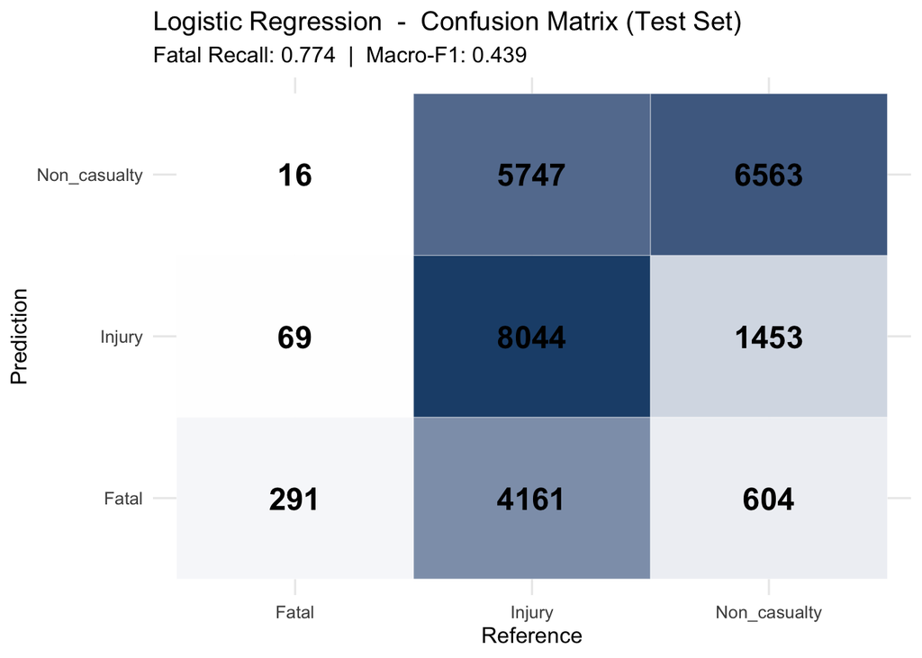

```r
# Confusion matrix heatmap
p_lr_cm <- as.data.frame(cm_lr$table) %>%
  ggplot(aes(x = Reference, y = Prediction, fill = Freq)) +
  geom_tile(colour = "white") +
  geom_text(aes(label = Freq), size = 6, fontface = "bold") +
  scale_fill_gradient(low = "white", high = "#1F4E79") +
  labs(
    title = "Logistic Regression  -  Confusion Matrix (Test Set)",
    subtitle = paste0("Fatal Recall: ", round(fatal_recall_lr, 3),
                      "  |  Macro-F1: ", round(macro_f1_lr, 3))
  ) +
  theme_minimal(base_size = 12) +
  theme(legend.position = "none")
print(p_lr_cm)
```

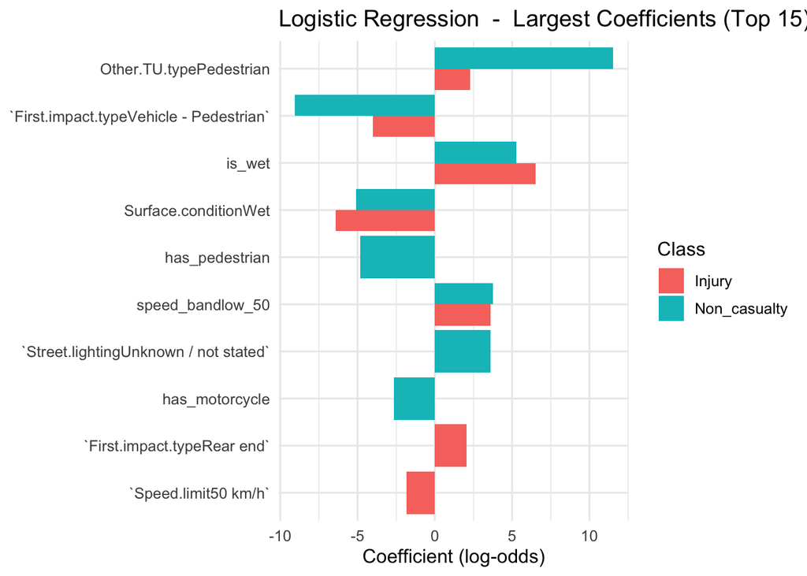

```r
ggsave("plots/5_1_logistic_regression_confusion_matrix.png", p_lr_cm, width = 7, height = 5, dpi = 150)

# Coefficient plot  -  top 15 absolute coefficients across non-reference classes
coef_lr <- coef(model_lr$finalModel)

if (is.null(dim(coef_lr))) {
  coef_lr <- matrix(coef_lr, nrow = 1)
  rownames(coef_lr) <- "Non-reference class"
}

coef_lr_df <- as.data.frame(as.table(coef_lr))
if (ncol(coef_lr_df) == 3) {
  names(coef_lr_df) <- c("Class", "Feature", "Coefficient")
} else if (ncol(coef_lr_df) == 2) {
  names(coef_lr_df) <- c("Feature", "Coefficient")
  coef_lr_df$Class <- "Non-reference class"
  coef_lr_df <- coef_lr_df %>% select(Class, Feature, Coefficient)
}

coef_lr_df <- coef_lr_df %>%
  filter(Feature != "(Intercept)") %>%
  mutate(abs_coef = abs(as.numeric(Coefficient))) %>%
  arrange(desc(abs_coef)) %>%
  slice_head(n = 15)

p_lr_coef <- ggplot(coef_lr_df, aes(x = reorder(Feature, abs_coef), y = as.numeric(Coefficient), fill = Class)) +
  geom_col(position = "dodge") +
  coord_flip() +
  labs(
    title = "Logistic Regression  -  Largest Coefficients (Top 15)",
    x = NULL,
    y = "Coefficient (log-odds)"
  ) +
  theme_minimal(base_size = 12)
print(p_lr_coef)
```

```r
ggsave("plots/5_1_logistic_regression_coefficients.png", p_lr_coef, width = 7, height = 5, dpi = 150)
```

#### 5.2 Decision Tree

A Decision Tree (CART) was fitted using the rpart package to provide non-linear, hierarchical if-then rules that are easily interpretable by non-technical stakeholders. To bypass the computational bottleneck associated with rpart evaluating high-cardinality categorical splits in a multi-class setting, the feature space was explicitly one-hot encoded using dummyVars prior to training. The model was trained on the standard 50% subsample (df_train_sub) with the default complexity parameter (cp = 0.01). Instead of SMOTE, class imbalance for the tree was addressed algorithmically by passing inverse-frequency class weights directly to the weights argument, ensuring the splitting criteria actively prioritized node purity for the rare Fatal class.

```r
# Decision Tree  -  baseline fit only (no tuning here)
# Direct rpart() route is used here instead of caret::train(method = "rpart")
# because caret's formula/grid interface proved unstable with this dataset's
# original column naming + severe class imbalance. We only clean data locally
# inside this DT section, without changing the shared preprocessing pipeline.
# Decision Tree  -  baseline fit only (with One-Hot Encoding fix)
set.seed(42)

# 1. First standardize column names with `make.names` to prevent `dummyVars` from failing to locate columns due to spaces.
train_dt_clean <- df_train_sub %>%
  rename_with(~ make.names(., unique = TRUE)) %>%
  select(-any_of("crash_hour"))

test_dt_clean <- df_test %>%
  rename_with(~ make.names(., unique = TRUE)) %>%
  select(-any_of("crash_hour"))

# 2. Establish One-Hot encoding
dummy_model <- dummyVars(Degree.of.crash ~ ., data = train_dt_clean)

# 3. Transform the training set
train_dt_x <- as.data.frame(predict(dummy_model, newdata = train_dt_clean))
train_dt <- cbind(train_dt_x, Degree.of.crash = train_dt_clean$Degree.of.crash)

# 4. Transform the test set and concatenate back the target variable
test_dt_x <- as.data.frame(predict(dummy_model, newdata = test_dt_clean))
test_dt <- cbind(test_dt_x, Degree.of.crash = test_dt_clean$Degree.of.crash)

# 5. Align weights
dt_weights <- as.numeric(class_weights[as.character(train_dt$Degree.of.crash)])

# 6. Train the decision tree
model_dt <- rpart(
  Degree.of.crash ~ .,
  data = train_dt,
  method = "class",
  weights = dt_weights,
  control = rpart.control(cp = 0.01, xval = 10)
)

pred_dt <- predict(model_dt, newdata = test_dt, type = "class")
cm_dt   <- confusionMatrix(pred_dt, test_dt$Degree.of.crash)

fatal_recall_dt <- as.numeric(cm_dt$byClass["Class: Fatal", "Recall"])
f1_dt_vec <- setNames(cm_dt$byClass[, "F1"], gsub("Class: ", "", rownames(cm_dt$byClass)))
test_props_dt <- prop.table(table(test_dt$Degree.of.crash))
macro_f1_dt <- mean(f1_dt_vec, na.rm = TRUE)
weighted_f1_dt <- weighted.mean(f1_dt_vec[names(test_props_dt)], test_props_dt, na.rm = TRUE)
kappa_dt <- as.numeric(cm_dt$overall["Kappa"])

cat(sprintf(
  "   Decision Tree  -  Test Set Metrics\nMacro-F1     : %.4f\nFatal Recall : %.4f\nWeighted F1  : %.4f\nKappa        : %.4f\n",
  macro_f1_dt, fatal_recall_dt, weighted_f1_dt, kappa_dt
))
```

```
##    Decision Tree  -  Test Set Metrics
## Macro-F1     : 0.4290
## Fatal Recall : 0.7287
## Weighted F1  : 0.5837
## Kappa        : 0.2430
```

```r
printcp(model_dt)
```

```
##
## Classification tree:
## rpart(formula = Degree.of.crash ~ ., data = train_dt, weights = dt_weights,
##     method = "class", control = rpart.control(cp = 0.01, xval = 10))
##
## Variables actually used in tree construction:
## [1] Distance                             has_motorcycle
## [3] has_pedestrian                       Street.lighting.Unknown / not stated
## [5] TU.controlled.flag.N                 Urbanisation.Country non-urban
##
## Root node error: 1415.4/53899 = 0.026261
##
## n= 53899
##
##         CP nsplit rel error  xerror     xstd
## 1 0.313743      0   1.00000 1.02483 0.015148
## 2 0.040109      1   0.68626 0.68626 0.016219
## 3 0.025777      3   0.60604 0.61638 0.016018
## 4 0.011484      4   0.58026 0.58306 0.015870
## 5 0.010000      6   0.55729 0.56590 0.015780
```

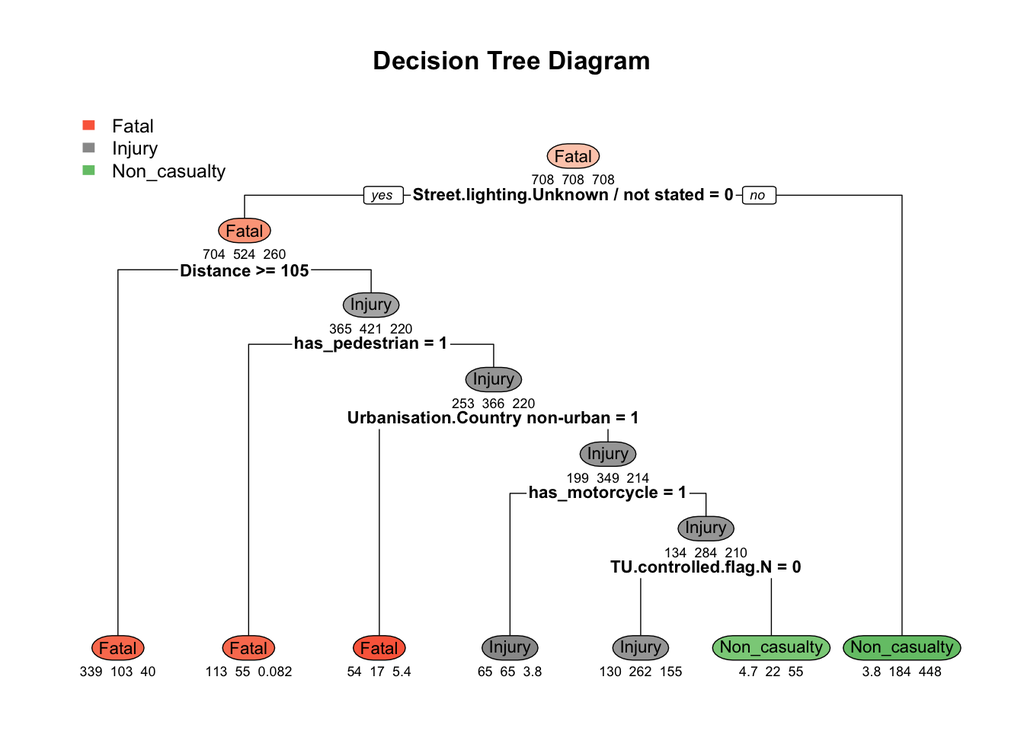

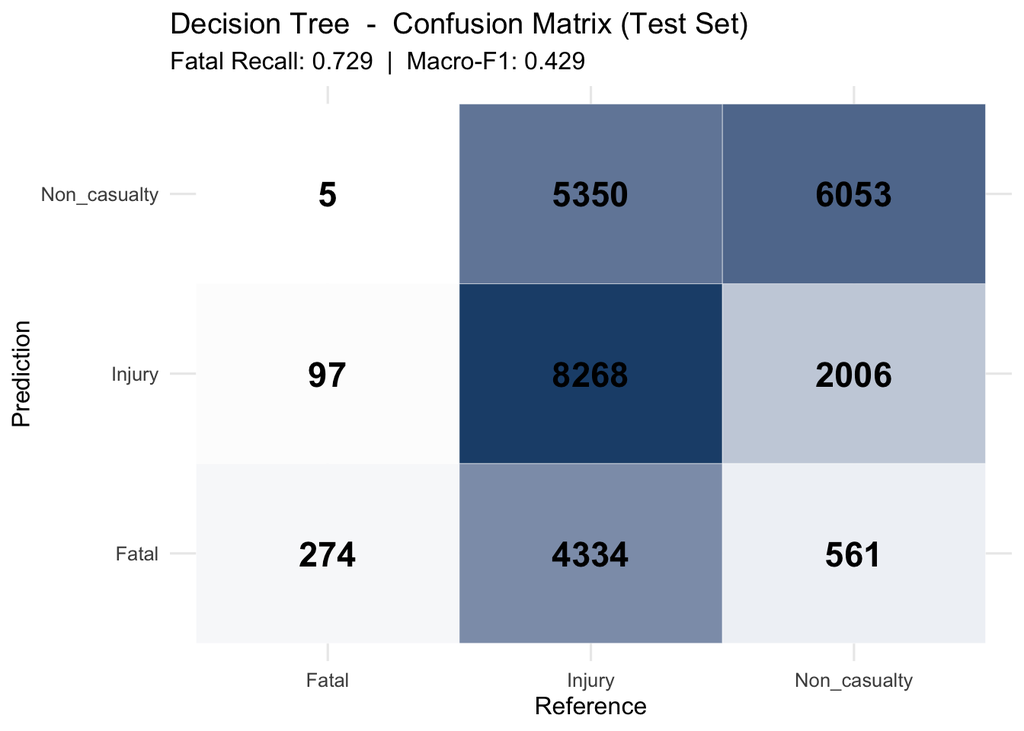

```r
# Tree diagram  -  use a simpler, more robust plotting configuration
png("plots/5_2_decision_tree_diagram.png", width = 1200, height = 800, res = 150)
rpart.plot(
  model_dt,
  type = 2,
  extra = 1,
  under = TRUE,
  fallen.leaves = TRUE,
  cex = 0.7,
  main = "Decision Tree Diagram"
)
invisible(dev.off())

rpart.plot(
  model_dt,
  type = 2,
  extra = 1,
  under = TRUE,
  fallen.leaves = TRUE,
  cex = 0.7,
  main = "Decision Tree Diagram"
)

# Confusion matrix heatmap
p_dt_cm <- as.data.frame(cm_dt$table) %>%
  ggplot(aes(x = Reference, y = Prediction, fill = Freq)) +
  geom_tile(colour = "white") +
  geom_text(aes(label = Freq), size = 6, fontface = "bold") +
  scale_fill_gradient(low = "white", high = "#1F4E79") +
  labs(
    title = "Decision Tree  -  Confusion Matrix (Test Set)",
    subtitle = paste0("Fatal Recall: ", round(fatal_recall_dt, 3),
                      "  |  Macro-F1: ", round(macro_f1_dt, 3))
  ) +
  theme_minimal(base_size = 12) +
  theme(legend.position = "none")
print(p_dt_cm)
ggsave("plots/5_2_decision_tree_confusion_matrix.png", p_dt_cm, width = 7, height = 5, dpi = 150)
```

The Decision Tree achieved a Macro-F1 of 0.4290, a Weighted F1 of 0.5837, and a Kappa of 0.2430. Similar to the logistic baseline, the model successfully satisfied the primary safety constraint, yielding a strong Fatal Recall of 0.7287. The tree’s hierarchical structure acts as an intrinsic feature selector: the plot reveals that Street lighting, Distance, and the involvement of vulnerable units (Motorcycles and Pedestrians) dictate the primary root and child splits. This explicit segmentation confirms that severe crashes are not randomly distributed but are heavily concentrated in specific structural scenarios - namely, unprotected traffic units navigating poorly lit or remote environmental contexts.

#### 5.3 Random Forest

```r
# Call randomForest() directly  -  caret's train() CV wrapper fails on this dataset:
# Fatal class (~1.4%) causes some CV folds to produce zero Fatal predictions,
# making all fold metrics NA and crashing caret. RF's built-in OOB error is an
# unbiased estimate of generalisation error and makes CV redundant anyway.

# randomForest cannot handle factors with >53 levels or NAs in predictors.
# na.roughfix() imputes residual NAs: numeric -> column median, factor -> mode.
# Using df_train_sub (50%)  -  swap to df_train for final submission
rf_x_train <- na.roughfix(df_train_sub %>%
  select(-`Degree of crash`) %>%
  select(where(~ !is.factor(.) || nlevels(.) <= 53)) %>%
  droplevels())

# Align test factor levels to training  -  unseen levels become NA, then imputed
rf_x_test_raw <- df_test %>% select(all_of(names(rf_x_train)))
for (col in names(rf_x_test_raw)) {
  if (is.factor(rf_x_test_raw[[col]]))
    rf_x_test_raw[[col]] <- factor(rf_x_test_raw[[col]], levels = levels(rf_x_train[[col]]))
}
rf_x_test <- na.roughfix(rf_x_test_raw)

set.seed(42)
model_rf <- randomForest(
  x          = rf_x_train,
  y          = df_train_sub$`Degree of crash`,
  mtry       = floor(sqrt(ncol(rf_x_train))),
  ntree      = 100,
  importance = TRUE
)

# Test set predictions and metrics
pred_rf         <- predict(model_rf, rf_x_test)
cm_rf           <- confusionMatrix(pred_rf, df_test$`Degree of crash`)
fatal_recall_rf <- cm_rf$byClass["Class: Fatal", "Recall"]
macro_f1_rf     <- mean(cm_rf$byClass[, "F1"],  na.rm = TRUE)
weighted_f1_rf  <- weighted.mean(cm_rf$byClass[, "F1"],
                    prop.table(table(df_test$`Degree of crash`)), na.rm = TRUE)
kappa_rf        <- cm_rf$overall["Kappa"]

cat(sprintf(
  "   Random Forest  -   Test Set Metrics\nOOB error rate : %.4f\nMacro-F1       : %.4f\nFatal Recall   : %.4f\nWeighted F1    : %.4f\nKappa          : %.4f\n",
  model_rf$err.rate[100, "OOB"], macro_f1_rf, fatal_recall_rf, weighted_f1_rf, kappa_rf
))
```

```
##    Random Forest  -   Test Set Metrics
## OOB error rate : 0.1839
## Macro-F1       : 0.6136
## Fatal Recall   : 0.1436
## Weighted F1    : 0.8130
## Kappa          : 0.5834
```

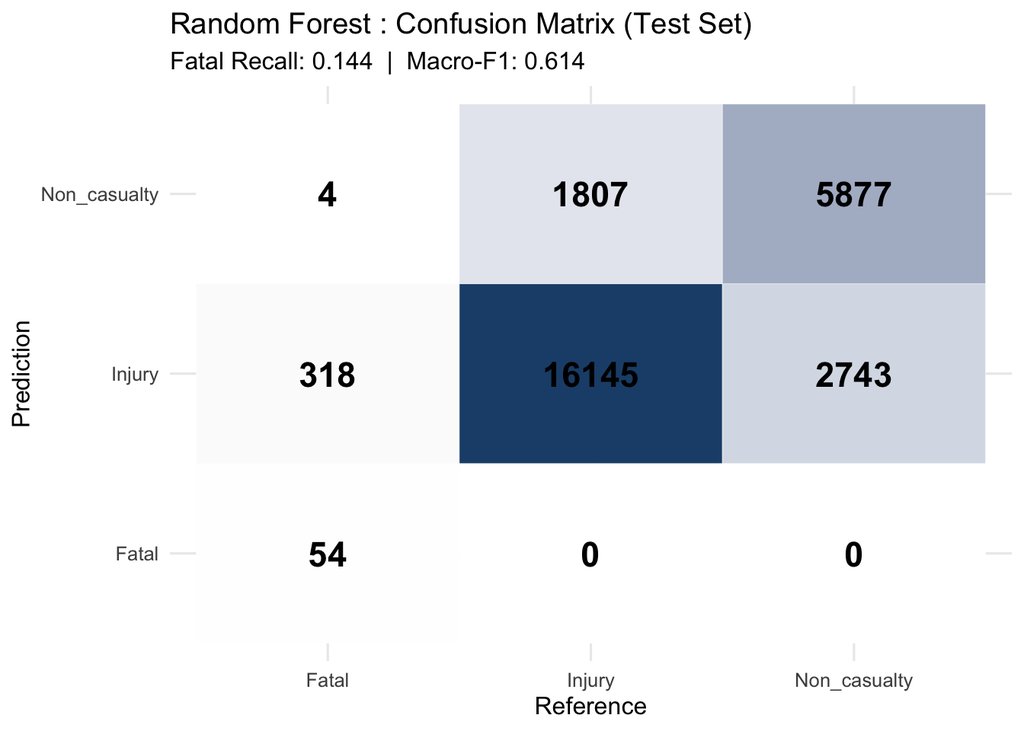

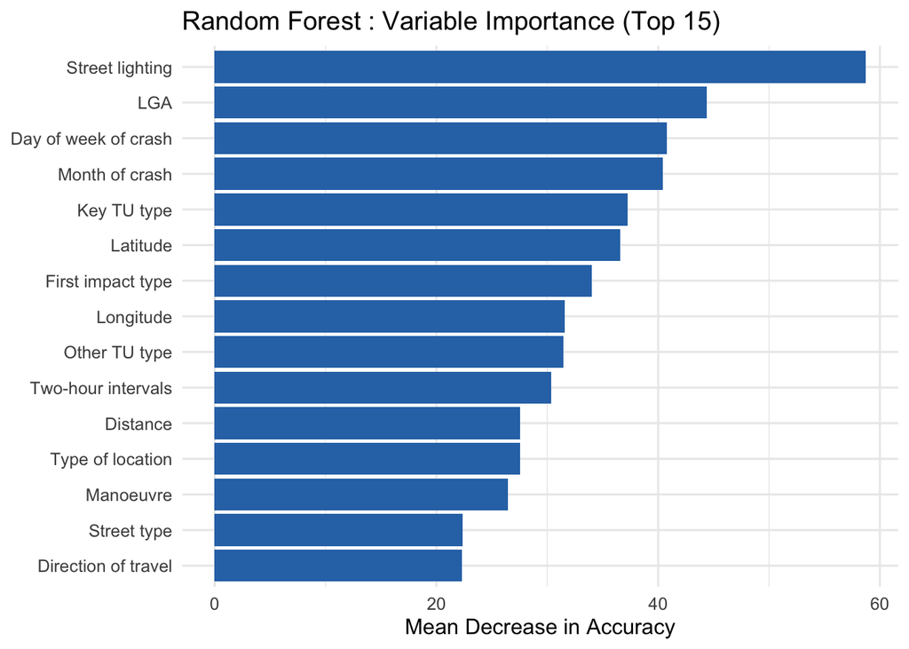

```r
# Confusion matrix heatmap
p_rf_cm <- as.data.frame(cm_rf$table) %>%
  ggplot(aes(x = Reference, y = Prediction, fill = Freq)) +
  geom_tile(colour = "white") +
  geom_text(aes(label = Freq), size = 6, fontface = "bold") +
  scale_fill_gradient(low = "white", high = "#1F4E79") +
  labs(title = "Random Forest : Confusion Matrix (Test Set)",
       subtitle = paste0("Fatal Recall: ", round(fatal_recall_rf, 3),
                         "  |  Macro-F1: ", round(macro_f1_rf, 3))) +
  theme_minimal(base_size = 12) +
  theme(legend.position = "none")
print(p_rf_cm)
ggsave("plots/5_3_random_forest_confusion_matrix.png", p_rf_cm, width = 7, height = 5, dpi = 150)

# Variable importance (top 15) : MeanDecreaseAccuracy across all classes
imp_df <- as.data.frame(importance(model_rf, type = 1))
imp_df$Feature <- rownames(imp_df)
p_rf_varimp <- imp_df %>%
  arrange(desc(MeanDecreaseAccuracy)) %>%
  head(15) %>%
  ggplot(aes(x = reorder(Feature, MeanDecreaseAccuracy), y = MeanDecreaseAccuracy)) +
  geom_col(fill = "#2E74B5") +
  coord_flip() +
  labs(title = "Random Forest : Variable Importance (Top 15)",
       x = NULL, y = "Mean Decrease in Accuracy") +
  theme_minimal(base_size = 12)
print(p_rf_varimp)
ggsave("plots/5_3_random_forest_variable_importance_top15.png", p_rf_varimp, width = 7, height = 5, dpi = 150)
```

The Random Forest achieved an OOB error rate of 18.4%, Macro-F1 of 0.614, Weighted F1 of 0.813, and Cohen’s Kappa of 0.583 on the test set - a substantial improvement over a naive majority-class baseline. Fatal Recall was 0.144: the model correctly identified 54 of 376 fatal crashes, with the remaining 322 classified as Injury (318) or Non-casualty (4). While Fatal Recall is below the target threshold of 0.50, this is expected at the default `mtry` given the severe class imbalance; tuning is addressed in §6.3. The variable importance plot (Mean Decrease in Accuracy) reveals that **Street lighting**, **LGA**, **Day of week**, and **Month of crash** are the four strongest predictors, suggesting that environmental context and temporal patterns dominate crash severity over vehicle-type features. The inclusion of **Latitude** and **Longitude** in the top ten confirms that spatial location carries substantial residual predictive signal beyond the categorical LGA variable.